# Data Mining using R: Capstone Project

News sentiments and stock performance: the case of Amazon.com

Simon Weigold

2023-04-28

# Introduction and theoretical framework

Predicting the stock market has been of great interest for researchers and business professionals likewise (Mittel & Goel, 2012; Nguyen et al., 2015; Parmar et al., 2018). The opportunities that come with investing in listed companies have created not only fascination for private investors but also professional career paths and whole industries (Amadeo, 2022; Indeed Editorial Team, 2023). The way the stock market works is that companies in certain instances decide to “go public” (Hall, 2021), i.e. the company offers shares for sale to the public, and anyone who would like to participate can buy these shares. With the availability of many shares from a wide range of different companies the stock market developed: a place, where investors buy and sell shares of publicly traded companies (Chen, 2023). The dynamics on the stock market are driven by the fluctuations of prices of stocks which can depend on factors such as companies’ performances, industry trends and overall market conditions (Huy et al., 2020).  
Since this dynamic establishes itself from an interchange between humans (executives at public companies, investors, financial advisors, just to name a few), communication can be expected to influence behaviours within this dynamic (Argan et al., 2014; Gardner et al., 2017). Mass communication in particular has a special role to play, as news channels such as newspapers, radio or television report on listed companies and thus create a certain image for the public’s perception and opinion-forming (Roberts & Bachen, 1981). News report on companies’ financial performances, changes in management, mergers and acquisitions and other relevant information that can affect the prices of stocks. It has been proven that investors form their perception of companies and stocks not only through metrics and balance sheets but also news publications. Ultimately, this influences the purchasing and selling behaviour of investors and therefore affects the stock price (Li et al., 2014; Shah et al., 2018).  
To analyse the correlation between news and stock performance, researchers have often used the tool of sentiment analysis in previous research projects (Mittel & Goel, 2012; Shah et al., 2018, Sousa et al., 2019). Sentiment analysis is a technique which can be used to identify positive, neutral, or negative opinions within a given text (Stine, 2019). Usually, the analysed text comes from news articles, social media posts or customer reviews (Mejova, 2009). To analyse sentiments in the context of stock performance, Twitter data has been studied for instance (Elbagir & Yang, 2019). To understand the effect of more traditional types of mass media, it may also be useful to analyse news articles and/or their headlines. Thus, this research project aims to answer the following research question:  
*To what extent do the stock performance of the company Amazon and the sentiment of news headlines of articles about Amazon from The Guardian correlate?*  
Since previous empirical evidence demonstrates significant relationships between mass media sentiments and stock performance, the following hypothesis is established:  
*There is a correlation between the sentiment of news headlines of articles about Amazon from the Guardian and the stock performance of the company Amazon.*

# Methodology

The first step of this research project is the data collection. This project analyses the stock data of Amazon and news headlines from The Guardian. First, the stock data is being retrieved.  
For this, the API by Alpha Vantage (2023) is used. After requesting an API key, the stock ticker of the company, which stock data shall be retrieved needs to be added to a predefined query URL. This query URL can then be used to send a GET request to the API and save the data on the local machine by using the “content” function of the “httr” package.  
After receiving a variety of data for the Amazon stock, it is decided to use the closing price, since it is the most commonly used indicator for evaluating a stock’s performance. This specific metric is extracted from the content file with the help of a for loop, which iterates through the list element of the exisiting file. In addition, the same procedure is used for the date of each data point. This creates two lists, which are transformed into a data frame, so that both date and closing data coexist in the respective row of the data frame. Finally, the data frame is stored in the working directory, to save the progress of work and use the data in further analysis steps.  
In order to collect news headlines for the sentiment analysis, data from a news source needs to be collected. The Guardian offers an API which enables developers and researchers to collect articles and respective data from over 2 million pieces of content (The Guardian, 2023). For R users, a package called “guardianapi” has been developed, which offers wrapper functions for easy access to the API by The Guardian. After registering on The Guardian Website for an API key, it can be stored into R and used to gain access to the data. For the request, the query term and time period are specified.  
The wrapper function already returns an object of the type data frame, which means that there is no need to parse any data. To facilitate the further analysis steps, only relevant variables are selected and encoded to UTF-8. Subsequently the data is stored on the working directory to use it for the further analyses.  
After collecting all data from the APIs, the first analysis can be conducted: a sentiment analysis using the Valence Aware Dictionary for Sentiment Reasoning (VADER). VADER is a part of the Natural Language Processing Toolkit (NLTK), a Python library. It is a lexicon-based approach for detecting sentiments in a given text. Although it is optimised for social media posts, it can be expected to function sufficiently on news headlines, since it assigns predefined values for connotations of language terms.  
Here, the polarity scores are calculated into a newly created variable, which is then used to extract the compound, a single metric ranging from -1 to 1, which summaries the overall sentiment within one single headline. Finally, a categorisation into positive, neutral and negative is implemented, using the borders of 0.05 and -0,05, as suggested by Xiang et al. (2021).  
The distribution of sentiments can be found in the following table:

```r
library(rio)
VADER <- import(here::here("ga_clean_VADER.csv"))
table(VADER$comp_score)
```

```
##
## neg neu pos
## 221 616 353
```

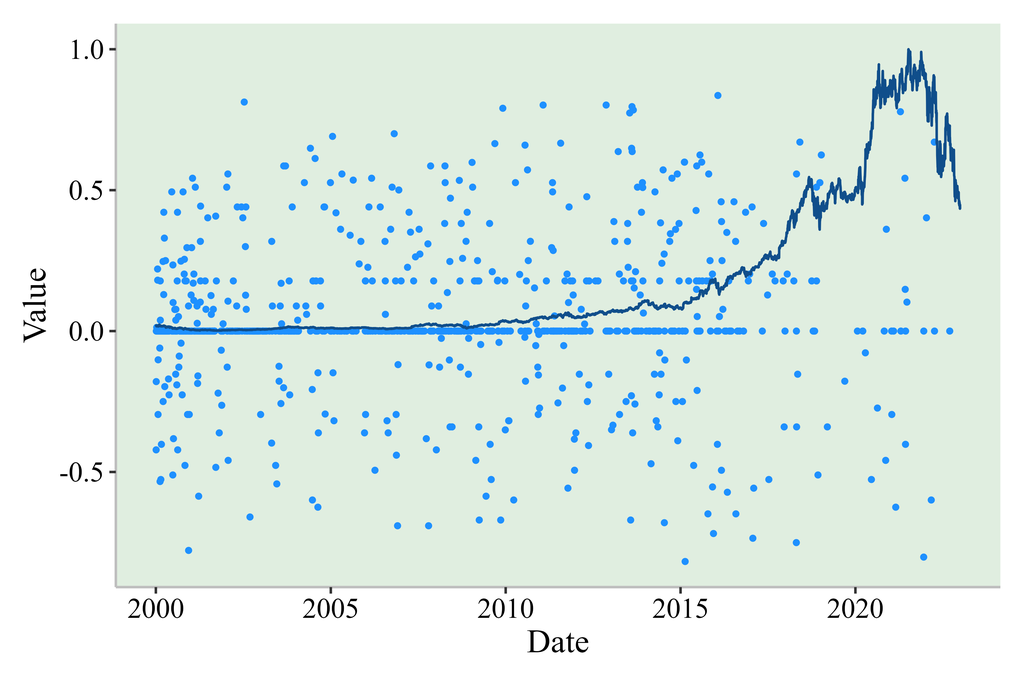

Subsequently, the correlation between stock performance and sentiment score is to be calculated. First, a scatter plot is created to visually examine the relationship between the two variables. As a third variable, date is kept but only shown as a gradient change of color.

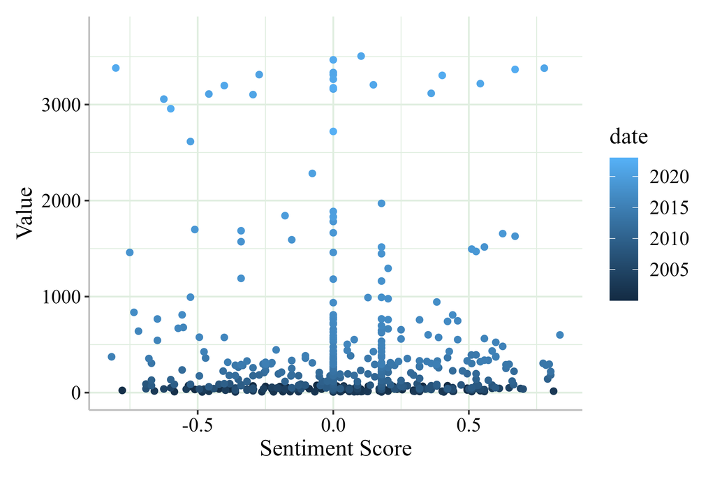

To calculate the correlation, Pearson’s R is used as a metric since it allows the inclusion of two continuous variables:

```r
df <- import(here::here("final_df.csv"))
cor.test(df$mean_compound, df$value, use="complete.obs")
```

```
##
##  Pearson's product-moment correlation
##
## data:  df$mean_compound and df$value
## t = -0.85235, df = 780, p-value = 0.3943
## alternative hypothesis: true correlation is not equal to 0
## 95 percent confidence interval:
##  -0.10039804  0.03968771
## sample estimates:
##         cor
## -0.03050496
```

# Results and Conclusion

The sentiment analysis shows that a large proportion of news headlines are neutral. There is a slight tendency towards positivity. The visualisation over time does not reveal any visible changes of sentiment over time. The stock value however grows larger.  
The visual examination of the correlation between stock performance and sentiment score confirms the positive trend of the stock value but does not show any correlation pattern between the two variables stock performance and sentiment score. The correlation metric Pearson’s R proves this. There is a non-significant (*p* > .05) relationship with a correlation coefficient of -.03. The small coefficient and the non-significance lead to a refusal of the hypothesis and it can be concluded that there is no correlation between the sentiment of news headlines of articles about Amazon from the Guardian and the stock performance of the company Amazon.  
To fully understand why the results of this research project do not align with previous empirical work, some further analyses should be made. For instance, it might be possible that the VADER sentiment analysis is not the ideal tool for analysing news headlines. Sousa et al. (2019) for instance used the transformer based language model BERT to examine a similar type of data and issue. Contextually it might also be possible that other news publishers would be more suitable to analyse correlations with stock data. News articles which specialise on financial issues for instance could perhaps show a bigger relationship towards the stock performance of a certain company. Finally, it would be interesting to analyse the contents of the news coverage of the company Amazon more in detail, to get a better understanding of reasons why sentiments of news headlines from news about Amazon from The Guardian do not correlate with the stock performance of the company.

# Literature

- *Alpha Vantage* (2023) ‘Stock Market API’. Available at: https://www.alphavantage.co/.
- Amadeo, K. (2022) “Pros and Cons of Investing in Stocks,” The Balance [Preprint]. Available at: https://www.thebalancemoney.com/stock-investing-for-the-individual-investor-3306182.
- Argan, M., Sevil, G., & Yalama, A. (2014). The effect of word-of-mouth communication on stock holdings and trades: Empirical evidence from an emerging market. Journal of Behavioral Finance, 15(2), 89-98.
- Chen, J. (2023) “What Is the Stock Market, What Does It Do, and How Does It Work?,” Investopedia [Preprint]. Available at: https://www.investopedia.com/terms/s/stockmarket.asp.
- Elbagir, S., & Yang, J. (2019). ‘Twitter sentiment analysis using natural language toolkit and VADER sentiment’, Proceedings of the international multiconference of engineers and computer scientists. March, Vol. 122, p. 16.
- Hall, M. (2021) “What”Going Public” Means,” Investopedia [Preprint]. Available at: https://www.investopedia.com/ask/answers/what-does-going-public-mean/.
- Gardner, L., Lee, S., Alford, M., & Cresson, J. (2017). The effects of information communication technology on stock market capitalization: A panel data analysis. Business and Economic Research, 7(1), 261-272.
- Huy, D. T. N., Loan, B. T. T., & Pham, T. A. (2020). Impact of selected factors on stock price: a case study of Vietcombank in Vietnam. Entrepreneurship and Sustainability Issues, 7(4), 2715.
- Indeed Editorial Team (2023) “11 Stock Market Careers To Explore (With Average Salaries),” Indeed Career Guide [Preprint]. Available at: https://www.indeed.com/career-advice/finding-a-job/stock-market-careers.
- Li, Q., Wang, T., Li, P., Liu, L., Gong, Q., & Chen, Y. (2014). The effect of news and public mood on stock movements. Information Sciences, 278, 826-840.
- Mejova, Y. (2009). ‘Sentiment analysis: An overview’, University of Iowa, Computer Science Department.
- Mittal, A., & Goel, A. (2012). Stock prediction using twitter sentiment analysis. Standford University, CS229 (2011 http://cs229. stanford. edu/proj2011/GoelMittal-StockMarketPredictionUsingTwitterSentimentAnalysis. pdf), 15, 2352.
- Nguyen, T. H., Shirai, K., & Velcin, J. (2015). Sentiment analysis on social media for stock movement prediction. Expert Systems with Applications, 42(24), 9603-9611.
- Parmar, I., Agarwal, N., Saxena, S., Arora, R., Gupta, S., Dhiman, H., & Chouhan, L. (2018, December). Stock market prediction using machine learning. In 2018 first international conference on secure cyber computing and communication (ICSCCC) (pp. 574-576). IEEE.
- Roberts, D. F., & Bachen, C. M. (1981). Mass communication effects. Annual review of psychology, 32(1), 307-356.
- Shah, D., Isah, H., & Zulkernine, F. (2018, December). Predicting the effects of news sentiments on the stock market. In 2018 IEEE International Conference on Big Data (Big Data) (pp. 4705-4708). IEEE.
- Sousa, M. G., Sakiyama, K., de Souza Rodrigues, L., Moraes, P. H., Fernandes, E. R., & Matsubara, E. T. (2019, November). BERT for stock market sentiment analysis. In 2019 IEEE 31st International Conference on Tools with Artificial Intelligence (ICTAI) (pp. 1597-1601). IEEE.
- Stine, R. A. (2019). ‘Sentiment analysis’, Annual review of statistics and its application, 6, pp. 287-308.
- *The Guardian* (2023) ‘Award-winning journalism Open to everyone’. Available at: https://open-platform.theguardian.com/.
- Xiang, N., Wang, L., Zhong, S., Zheng, C., Wang, B., & Qu, Q. (2021). ‘How does the world view China’s carbon policy? A sentiment analysis on Twitter data’, *Energies*, 14(22), 7782.